# Multiple flow FeNO in population research: R code methods demo

The following demo file provides example R code to implement six methods for cross-sectional studies with multiple flow exhaled nitric oxide (FeNO) measurements, where the goal is to relate estimated NO parameters to factors of interest (i.e., covariate(s) X) in the study population.

## 0. Preliminaries: set up your R session

IMPORTANT! Install JAGS, if not already installed, follow instructions at: https://mcmc-jags.sourceforge.io/

Load the following required packages, installing first if not already available. To use the R2jags package, JAGS must be pre-installed.

```r
# set working directory
setwd("K:/paper/newpackage/PopFeNO")
# load required packages
require(MASS)
require(lme4)
require(nlme)
require(reshape2)
require(R2jags)
require(knitr)
```

## 1. Data simulation (flow rate for HMA)

First, set a random seed for your work.

```r
set.seed(2020)
```

Next, we simulate data from a cross-sectional study with multiple flow FeNO on each partcipant and a single covariate of interest, X, which varies at the participant-level (i.e., it varies across participants, but is constant within participant across FeNO maneuvers). We have written a function DataGeneratorCS() in DataG.R, which outputs a simulated dataset containing data for each participant on mean flow and FeNO for all FeNO maneuvers as well as that participant’s value of X.

$$FeNO = C_{aw} + (C_A-C_{aw}) \times e^{-\frac{D_{aw}}{flow}}$$

```r
# Simulate a multiple flow FeNO dataset in a study population
source("DataG.R")       # code to generate multiple flow FeNO datasets
flow=c(rep(30,2),rep(50,2),rep(100,2),rep(300,2))
truebeta=c(0.1,0.1,0.1)
out <- DataGeneratorCS(Ndat=200,           # number of study participants
                      alpha=c(1.5,3.5,2.5),# vector of NO parameter population means,
                                           # when X=0, in this order: CA, logCaw, logDaw
                      # function to generate participant-level covariate X
                      # as function of number of study participants
                      Xfn=function(n){rnorm(n,0,1)},
                      # vector of regression coefficients relating X to NO parameters,
                      # in this order: CA, logCaw, logDaw
                      beta=truebeta,
                      # vector of flow rates in multiple flow FeNO protocol
                      Flow=c(rep(30,2),rep(50,2),rep(100,2),rep(300,2)),

                      SD=0.1,              #SD of the error
                      sdalphaCa            = 0.45, # population SD of CA
                      sdalphalogCaw        = 0.65, # population SD of logCaw
                      sdalphalogDaw        = 0.55, # population SD of logDaw
                      coralphalogCawCa     = 0.66, # correlation of logCaw, CA
                      coralphalogCawlogDaw = -0.35,# correlation of logCaw, logDaw
                      coralphalogDawCa     = -0.38 # correlation of logDaw, CA
                     )
# output is two versions of the same dataset, plus dataset only including X and id
# one dataset for use in Bayesian methods via JAGS (datJAGS)
# one dataset for all other methods (dat)
dat     <- out$dat
datJAGS <- out$datJAGS
datX    <- out$datX

out2<-DataGeneratorCS_UbN(Ndat=10,            # number of study participants
                          alpha=c(1.5,3.5,2.5),# vector of NO parameter population means, when X=0, in this order: CA, logCaw, logDaw
                          Xfn=function(n){rnorm(n,0,1)},# function to generate participant-level covariate X as function of number of study participants
                          beta=c(0.1,0.1,0.1),
                          flowTarget=c(rep(30,2),rep(50,2),rep(100,2),rep(300,2)),# vector of regression coefficients relating X to each NO parameter, in this order: CA, logCaw, logDaw
                          Flow=FlowFun(10,0.9), # Must be a Ndat*max length of flow matrix, missing values were 0s
                          SD=0.1,              #SD of the error
                          sdalphaCa            = 0.45, # population SD of CA
                          sdalphalogCaw        = 0.65, # population SD of logCaw
                          sdalphalogDaw        = 0.55, # population SD of logDaw
                          coralphalogCawCa     = 0.66, # correlation of NO parameters: logCaw, CA
                          coralphalogCawlogDaw = -0.35,# correlation of NO parameters: logCaw, logDaw
                          coralphalogDawCa     = -0.38 # correlation of NO parameters: logDaw, CA
)
dat <- out2$dat
datX<- out2$datX
```

- The resultant dataset is in the usual ‘long’ data format:

| id | eno | logeno | flow | flowTarget |
| --- | --- | --- | --- | --- |
| 1 | 18.550100 | 2.920475 | 31.01645 | 30 |
| 1 | 18.016264 | 2.891275 | 30.58051 | 30 |
| 1 | 14.224177 | 2.654943 | 48.81613 | 50 |
| 1 | 12.760105 | 2.546324 | 50.36992 | 50 |
| 1 | 7.676364 | 2.038146 | 98.97814 | 100 |
| 1 | 8.119653 | 2.094287 | 99.61364 | 100 |
| 1 | 3.702673 | 1.309055 | 298.62592 | 300 |
| 1 | 3.665347 | 1.298923 | 301.72294 | 300 |
| 2 | 3.507760 | 1.254978 | 30.90222 | 30 |
| 2 | 3.284286 | 1.189149 | 29.16724 | 30 |

- The intercepts and slopes of the linear regression moedls: NOparam ~ X of the simulated data, used in the plotting section:

|  | Ca | logCaw | logDaw |
| --- | --- | --- | --- |
| (Intercept) | 1.6343842 | 3.9089567 | 2.3183797 |
| datX[, 2] | 0.1965633 | 0.2297409 | -0.0420262 |

## 2. Estimate NO parameter associations with X

### 2.1 TS_NLS: Two-stage nonlinear least squares

1: NLS_StageI: Estimated NO paramteres ordered by id, exist NAs

2: NLS_StageIX: Combine NO paramters and covariate X by id

3: Fit individual grouped linear regression models for each NO parameters

```r
source("TS_NLS.R")

# Stage I
NLS_StageI <- TS_NLS_StageI(dat)

# create dataset including both Stage I estimates and X
NLS_StageIX <- merge(NLS_StageI, datX, by = "id")

# Stage II - edit to include any additional Stage II
# covariates (e.g., confounder adjustments)
TS_NLS_Ca <- lme(Ca ~ X, random = ~1 | id, data = NLS_StageIX,
    na.action = na.omit)
TS_NLS_logCaw <- lme(logCaw ~ X, random = ~1 | id, data = NLS_StageIX,
    na.action = na.omit)
TS_NLS_logDaw <- lme(logDaw ~ X, random = ~1 | id, data = NLS_StageIX,
    na.action = na.omit)
```

**Interpretation for CANO:**

The population mean CANO is 0.92 (95% CI: -0.39,2).

For 1 unit increase in covariate X, CANO increases 0.18, (95% CI: -0.88, 1.25).

**Interpretation for CawNO and DawNO from their log version:**

The population mean CawNO is 3.69 (95% CI: 3.17,4).

For 1 unit increase in covariate X, CawNO increases -13.9%, (95% CI: -43.28%, 30.69%).

The population mean DawNO is 2.84 (95% CI: 1.93,4).

For 1 unit increase in covariate X, DawNO increases 22.04%, (95% CI: -41.41%, 154.19%).

- These interpretations are similar for following results.

### 2.2 TS_HMA: Two-stage Högman & Merilänen Algorithm

```r
source("TS_HMA.R")

# Stage I, specify target flow rates for HMA (low, medium,
# high)
HMA_StageI <- TS_HMA_StageI(dat, flowLMH = c(30, 100, 300))

# create dataset including both Stage I estimates and X
HMA_StageIX <- merge(HMA_StageI, datX, by = "id")

# Stage II - edit to include any additional Stage II
# covariates (e.g., confounder adjustments)
TS_HMA_Ca <- lme(Ca ~ X, random = ~1 | id, data = HMA_StageIX,
    na.action = na.omit)
TS_HMA_logCaw <- lme(logCaw ~ X, random = ~1 | id, data = HMA_StageIX,
    na.action = na.omit)
TS_HMA_logDaw <- lme(logDaw ~ X, random = ~1 | id, data = HMA_StageIX,
    na.action = na.omit)
```

### 2.3 TS_NLME: Two-stage nonlinear mixed effects model

```r
if (!file.exists("TSNLME_cc.Rdata")) {
    set.seed(2020)
    source("TS_NLME.R")
    # Stage I
    TSNLME_StageIout <- TS_NLME_StageI(dat, tol1 = 0.1, tol2 = 0.1,
        outputFit = TRUE)  # include X for later unified version
    save(TSNLME_StageIout, file = "TSNLME_cc.Rdata")
} else {
    load("TSNLME_cc.Rdata")
}
TSNLME_StageI <- TSNLME_StageIout$ests
TSNLME_StageIfit <- TSNLME_StageIout$fit  # save fit to speed up U_NLME

# create dataset including both Stage I estimates and X
TSNLME_StageIX <- merge(TSNLME_StageI, datX, by = "id")

# Stage II - edit to include any additional Stage II
# covariates (e.g., confounder adjustments)
TS_NLME_Ca <- lme(Ca ~ X, random = ~1 | id, data = TSNLME_StageIX,
    na.action = na.omit)
TS_NLME_logCaw <- lme(logCaw ~ X, random = ~1 | id, data = TSNLME_StageIX,
    na.action = na.omit)
TS_NLME_logDaw <- lme(logDaw ~ X, random = ~1 | id, data = TSNLME_StageIX,
    na.action = na.omit)
```

### 2.4 UNLME: Unified nonlinear mixed effects model

- Notation: There are two ways to fit the unified NLME model. One through direct simulation, the other updates the two-stage version.

```r
if (!file.exists("UNLME_cc.Rdata")) {
    set.seed(2020)
    # The function is for single X. If you want to fit with
    # multiple X, just modify the 'fixed' and start
    # statement of the function
    source("U_NLME.R")
    # direct approach
    U_NLMEout <- U_NLME_direct(dat, datX, tol = 0.1)
    # update approach
    # U_NLMEout_u<-U_NLME_update(TSNLME_StageIout,dat,datX,tol=0.1)
    # anova(U_NLMEout,U_NLMEout_u) # compare two approaches
    save(U_NLMEout, file = "UNLME_cc.Rdata")
} else {
    load("UNLME_cc.Rdata")
}
```

### 2.5 TS_HB: Two-stage Hierarchical Bayesian method

- Load existing results if exists.

```r
# Stage I if(!file.exists('TSHB_cc.Rdata')){
set.seed(2020)
source("TS_HB.R")


TSHB_S1 <- TSHB_iter_UB(beta0_prior = c(2, 4, 3), rhat = 1.1,
    addon.iter = 60, Max_update = 10, n.final = 60, N.iterT = 550,
    N.burnin = 500, N.thinM = 1, N.chain = 3, flow = flow, dat = dat,
    tracing = c("beta0_Ca", "beta0_logCaw", "beta0_logDaw", "sdCa",
        "sdlogCaw", "sdlogDaw", "corlogCawCa", "corlogCawlogDaw",
        "corlogDawCa", "sigma_c"))
save(TSHB_S1, file = "TSHB_cc_ub.Rdata")
# }else{ load('TSHB_cc.Rdata') }

TSHB_S1_dat <- data.frame(Ca = TSHB_S1$summary[grepl("^Ca", rownames(TSHB_S1$summary)),
    1], logCaw = TSHB_S1$summary[grepl("^logCaw", rownames(TSHB_S1$summary)),
    1], logDaw = TSHB_S1$summary[grepl("^logDaw", rownames(TSHB_S1$summary)),
    1])
TSHB_S1_dat$id <- as.numeric(unlist(lapply(rownames(TSHB_S1_dat),
    function(x) strsplit(strsplit(x, "\\[")[[1]][2], "\\]")[[1]])))
TSHB_S1_dat <- TSHB_S1_dat[order(TSHB_S1_dat$id), ]
TSHB_StageIX <- cbind(TSHB_S1_dat, datX)

# Stage II - edit to include any additional Stage II
# covariates (e.g., confounder adjustments)
TS_HB_Ca <- lme(Ca ~ X, random = ~1 | id, data = TSHB_StageIX,
    na.action = na.omit)
TS_HB_logCaw <- lme(logCaw ~ X, random = ~1 | id, data = TSHB_StageIX,
    na.action = na.omit)
TS_HB_logDaw <- lme(logDaw ~ X, random = ~1 | id, data = TSHB_StageIX,
    na.action = na.omit)
```

##### 2.5.ex Convergence diagnostic for TS_HB via Rhat (See Gelman and Rubin (1992), Brooks and Gelman (1998)])

- Print out the estimation (95% CL) and Rhat (converge if <1.1 )

|  | 2.5% | mean | 97.5% | Rhat |
| --- | --- | --- | --- | --- |
| beta0_Ca | -993.9257764 | -196.2995768 | 1.8616967 | 2.913813 |
| beta0_logCaw | 2.7353890 | 3.8047858 | 4.4149104 | 2.105715 |
| beta0_logDaw | 1.4905670 | 2.3803340 | 2.9132965 | 7.130810 |
| sdCa | 0.2885420 | 27.5031470 | 169.7547641 | 8.627952 |
| sdlogCaw | 0.2956694 | 0.7092545 | 1.4566963 | 3.829610 |
| sdlogDaw | 0.1425450 | 0.4524099 | 1.0625146 | 2.793215 |
| corlogCawCa | -0.0871290 | 0.6430785 | 0.9482338 | 1.458423 |
| corlogCawlogDaw | -0.3722056 | 0.6159421 | 0.9770478 | 1.897797 |
| corlogDawCa | -0.2480491 | 0.4774214 | 0.8763660 | 1.382292 |
| sigma_c | 0.0864459 | 0.1025492 | 0.1201962 | 1.068549 |

#### 2.6 U_HB: Unified Hierarchical Bayesian method

- Load existing results if exists.

```r
source("U_HB.R")

# if(!file.exists('UHB_cc.Rdata')){
set.seed(2020)
UHB_sim <- UHB_iter_UB(beta0_prior = c(2, 4, 3), betaC_prior = c(0.1,
    0.1, 0.1), rhat = 1.1, addon.iter = 100, Max_update = 1,
    n.final = 100, N.iterT = 1200, N.burnin = 1000, N.thinM = 1,
    N.chain = 3, flow = flow, dat = dat, X = datX[, 2], tracing = c("beta0_Ca",
        "beta0_logCaw", "beta0_logDaw", "beta1_Ca", "beta1_logCaw",
        "beta1_logDaw", "sdCa", "sdlogCaw", "sdlogDaw", "corlogCawCa",
        "corlogCawlogDaw", "corlogDawCa", "sigma_c"))
save(UHB_sim, file = "UHB_cc_ub.Rdata")
# }else{ load('UHB_cc.Rdata') }
```

##### 2.6.ex Convergence diagnostic for U_HB via Rhat

- Print out the estimation (95% CL) and Rhat (converge if <1.1 )

|  | 2.5% | mean | 97.5% | Rhat |
| --- | --- | --- | --- | --- |
| beta0_Ca | -2484.8934838 | -1114.5250868 | -204.6047328 | 1.053201 |
| beta0_logCaw | 3.5367370 | 4.4002989 | 5.5108719 | 5.086159 |
| beta0_logDaw | 0.4978336 | 1.8039490 | 2.6926961 | 4.485909 |
| beta1_Ca | -527.1484290 | 7.8222306 | 487.8997552 | 1.382090 |
| beta1_logCaw | -0.5422396 | -0.0325873 | 0.8512145 | 5.371599 |
| beta1_logDaw | -0.7005638 | 0.2644322 | 1.4139378 | 3.744597 |
| sdCa | 17.9203646 | 65.1039120 | 151.9736111 | 1.062158 |
| sdlogCaw | 0.1019269 | 0.4961355 | 1.2141681 | 5.502402 |
| sdlogDaw | 0.2021531 | 0.8597509 | 1.8339613 | 2.600239 |
| corlogCawCa | -0.7908604 | -0.0153289 | 0.9222895 | 1.162105 |
| corlogCawlogDaw | -0.8490496 | -0.1363497 | 0.5805836 | 1.727325 |
| corlogDawCa | -0.7196850 | 0.1077570 | 0.9033382 | 1.089476 |
| sigma_c | 0.0883555 | 0.1056248 | 0.1268269 | 1.062361 |

## 3. Create plot comparing estimated NO parameter associations across 6 methods

- Y axis: 6 methods
- X axis: coefficient effect size: The values used in simulation were all equaled to 0.1 for CANO, logCawNO and logDawNO. Which means for 1 unit increase in the covariate X, the corresponding NO paramters CANO, logCawNO and logDawNO increase 0.1 unit. The geometric interpretation for CawNO was that it was (exp(0.1)-1) times higher for 1 unit increase in the covariate, so was for DawNO
- Refernce lines: Black lines indicate the values used in data simulation. Gray lines indicate the values obtained by regression on the simulated NO parameters and Xs.

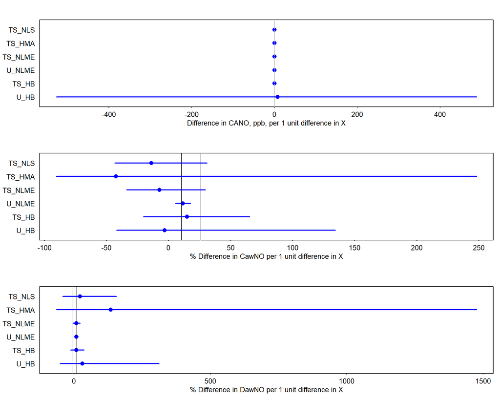